# История и перспективы приватизации в Украине

##### Рис 12. Доля предприятий по группам, договор купли-продажи которых содержит дополнительные условия. (%)

```r
x <- c("A", "B,G", "D")
underControl <- data.frame()
for(i in x){
        temp <- PrivStateControl %>% filter(object.class == i) %>%
                summarise(object.class = i, `% under state control` = number.of.objects[2]/sum(number.of.objects)*100)

        underControl <- rbind(underControl, temp)
}

underControl
```

```
##   object.class % under state control
## 1            A              55.97987
## 2          B,G              15.27268
## 3            D              80.99835
```

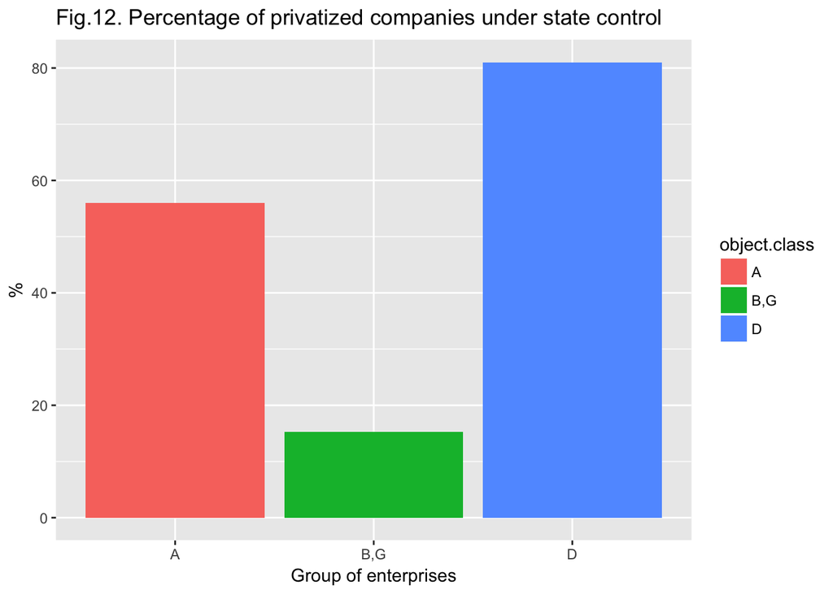

```r
ggplot(data = underControl, aes(x = object.class, y = `% under state control`, fill = object.class))+
        geom_bar(stat = "identity")+
        xlab("Group of enterprises")+
        ylab("%")+
        ggtitle("Fig.12. Percentage of privatized companies under state control")
```

Другими словами, в 85% случаях частный собственник, приобретая крупное или стратегически важное предприятие, не брал на себя никаких обязательств ни по привлечению инвестиций, ни по сохранению вида деятельности, ни по объемам выпускаемой продукции, ни по сохранению рабочих мест.

При этом, даже те собственники, которые брали на себя обязательства, соблюдали их отнюдь не всегда. Так, только официальные плановые проверки Фонда госимущества выявляли ежегодно нарушения условий договоров купли-продажи в среднем в 20% случаях от общего количества проверенных договоров. Как видно из графика (рис.13), наибольшее количество нарушений выявлялось на этапе «большой приватизации» - до 2000 года. После этого выявляемое проверками количество нарушений снизилось, и остается на уровне 14-15% ежегодно.

##### Рис.13. Нарушения, выявляемые проверками условий выполнения договоров купли-продажи приватизированных объектов по годам (% к проверяемым договорам)[^12].

```r
colnames(Violations_contracts) <- c("Year", "% contracts with violations")
Violations_contracts$Year <- as.factor(Violations_contracts$Year)

Violations_contracts
```

```
##             Year % contracts with violations
## 1  1996 \320\263                        36.6
## 2  1997 \320\263                        32.4
## 3  1998 \320\263                        26.6
## 4  1999 \320\263                        20.8
## 5  2000 \320\263                        19.7
## 6  2001 \320\263                        17.9
## 7  2002 \320\263                        16.7
## 8  2003 \320\263                        13.7
## 9  2004 \320\263                        13.5
## 10 2005 \320\263                        15.0
## 11 2006 \320\263                        13.0
## 12 2008 \320\263                        14.0
## 13 2009 \320\263                        13.0
## 14 2012 \320\263                        12.6
## 15 2014 \320\263                        14.5
## 16 2015 \320\263                        13.4
```

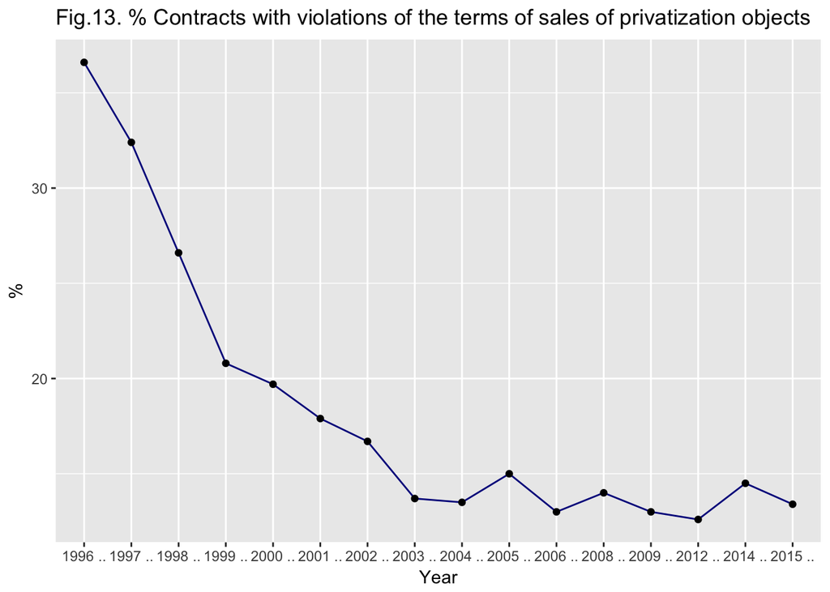

```r
ggplot(data = Violations_contracts, aes(x = Year, y = `% contracts with violations`, group = 1))+
        geom_line(colour="darkblue")+
        geom_point()+

        xlab("Year")+
        ylab("%")+
        ggtitle("Fig.13. % Contracts with violations of the terms of sales of privatization objects")
```

При этом, каждый слушатель, без сомнения, будучи патриотом и любя свою страну, все же понимает уровень коррупции в ней, и может интуитивно оценить, каким, скорее всего, является реальный уровень нарушений, если данные официальных отчетов держатся на отметке 14-15%. Как же наказываются предприятия, которые нарушают условия договоров купли-продажи? Они оплачивают штрафы. Зная из отчетов Фонда госимущества количество предприятий-нарушителей и общую сумму штрафов, начисленную по результатам ежегодных проверок, несложно подсчитать, во сколько обходится предприятию невыполнение обязательств (в том числе и сохранение основных видов деятельности, создание рабочих мест, привлечение инвестиций). Для возможности сравнивать разные временные периоды, переведем сумму штрафов в номинальные дол.США. (См.рис.14.)

##### Рис.14 Штрафы, начисленные за нарушение условий договоров купли-продажи объектов приватизации по годам на 1 нарушителя (ном.дол.США)[^13].

```r
Penalties_per_violation2 <- filter(Penalties_per_violation, Category == "Penalties per violator")
Penalties_per_violation2$year <- as.factor(Penalties_per_violation2$year)
Penalties_per_violation2
```

```
##   year               Category            units Number
## 1 2003 Penalties per violator USD per violator    151
## 2 2005 Penalties per violator USD per violator    230
## 3 2006 Penalties per violator USD per violator    199
## 4 2008 Penalties per violator USD per violator    153
## 5 2009 Penalties per violator USD per violator    340
## 6 2012 Penalties per violator USD per violator   1029
## 7 2014 Penalties per violator USD per violator    641
## 8 2015 Penalties per violator USD per violator    254
```

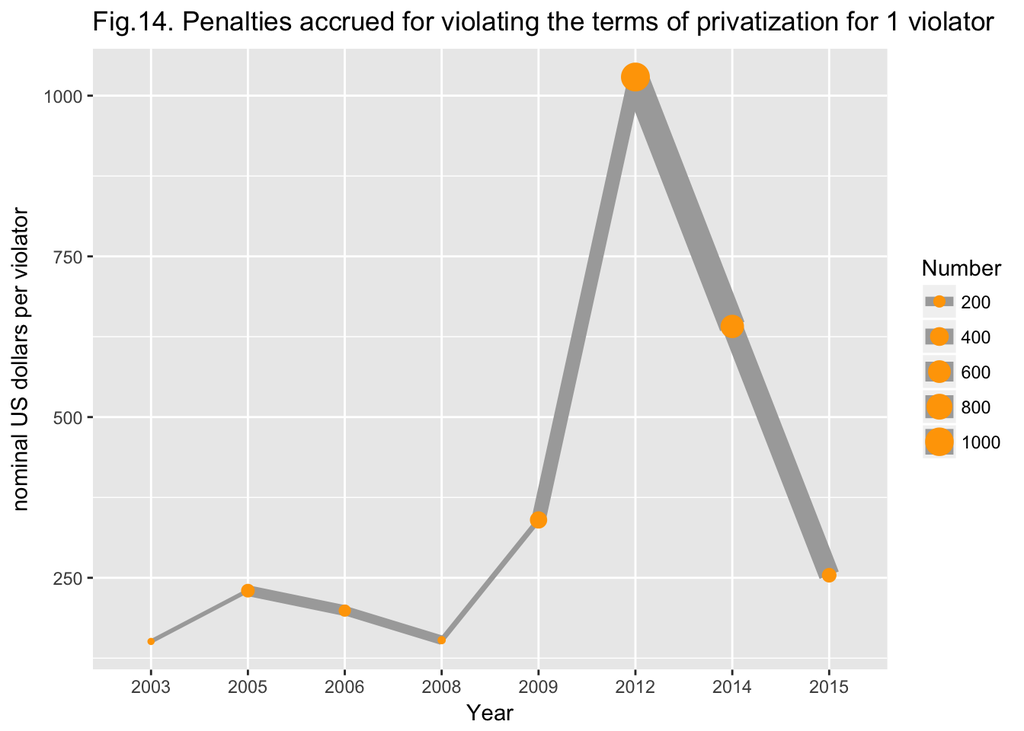

```r
ggplot(data = Penalties_per_violation2, aes(x = year, y = Number, size=Number, group = 1))+
        geom_line(colour="darkgray")+
        geom_point(colour = "orange")+

        xlab("Year")+
        ylab("nominal US dollars per violator")+
        ggtitle("Fig.14. Penalties accrued for violating the terms of privatization for 1 violator")
```

Сумма штрафа на одно предприятие составляла в среднем 374 доллара США в год, что навряд ли можно назвать серьезным сдерживающим фактором, мотивирующим руководство предприятия не нарушать обязательства по приватизационному договору. А вот «крайняя мера» - возврат предприятия в государственную собственность за все 20 лет была применена всего к 336 объектам. Т.е. из-за невыполнения условий приватизационных договоров было возвращено чуть больше 2% всех приватизированных предприятий, держащихся на контроле в Фонде госимущества. Основной вынужденной необходимостью приватизации промышленных предприятий считается всеми понятное «нет денег» у государства на модернизацию изношенных основных фондов, замену морально-устаревшего оборудования, квалифицированный менеджмент, маркетинг и т.д. Считается, что новый владелец – частник - обязательно вложит инвестиции в купленную собственность, создаст новые рабочие места, повысит зарплаты и предприятие получит «вторую жизнь». Давайте проанализируем по некоторым показателям успехи приватизированных в Украине предприятий[^14]:.

## Привлечение инвестиций.

В ежегодных отчетах Фонд госимущества так же публикует статистику по привлеченным в приватизированные предприятия инвестициям по накопительному итогу – картинка получается позитивная, линия графика инвестиций стремится вверх, достигая в 2015 году отметки почти в 30 млрд.грн. (Рис.15)[^15]

##### Рис.15. Инвестиции в приватизированные предприятия по накопительному итогу (млрд.грн)

```r
PrivatizedCompaniesInvestments
```

```
##          Year million.UAH million.USD
## 1  1995-2002         4620  1026.66667
## 2        2003         670   121.81818
## 3        2004         530    96.36364
## 4        2005        1060   209.90099
## 5        2006        1210   239.60396
## 6        2007        1310   259.40594
## 7        2008         510    63.75000
## 8        2009        6790   679.00000
## 9        2010        1170   117.00000
## 10       2011        1780   178.00000
## 11       2012        2360   236.00000
## 12       2013        2130   213.00000
## 13       2014        1360   136.00000
## 14       2015        2330    93.20000
```

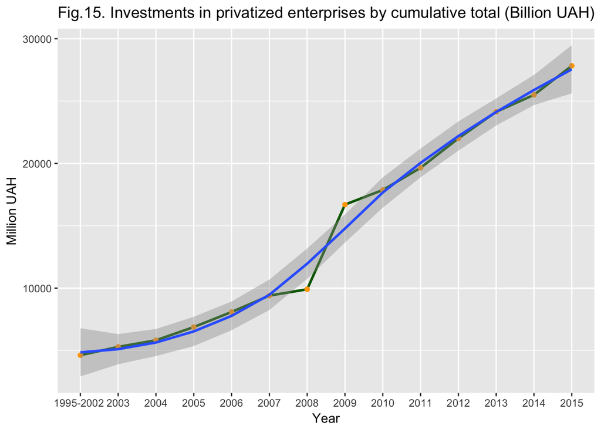

```r
# Пересчитываем таблицу, показывая ежегодный результат по накопительному методу
PCIcommulative <- data.frame(PrivatizedCompaniesInvestments[1,1], PrivatizedCompaniesInvestments[1,2])
for (i in 2:14){
       temp <-  data.frame(PrivatizedCompaniesInvestments[i,1], PrivatizedCompaniesInvestments[i,2] +
                                   PCIcommulative[i-1,2])
       names(PCIcommulative) <- names(temp)
       PCIcommulative <- rbind(PCIcommulative, temp)
}

colnames(PCIcommulative) <- c("Year", "Million UAH")

ggplot(data = PCIcommulative, aes(x = Year, y = `Million UAH`, group = 1))+
        geom_line(colour="darkgreen", size = 1)+
        geom_point(colour = "orange")+
        geom_smooth(method = "loess")+

        xlab("Year")+
        ylab("Million UAH")+
        ggtitle("Fig.15. Investments in privatized enterprises by cumulative total (Billion UAH)")
```

##### Рис.16. Инвестиции в приватизированные предприятия по годам (млн.ном.дол.США)[^16].

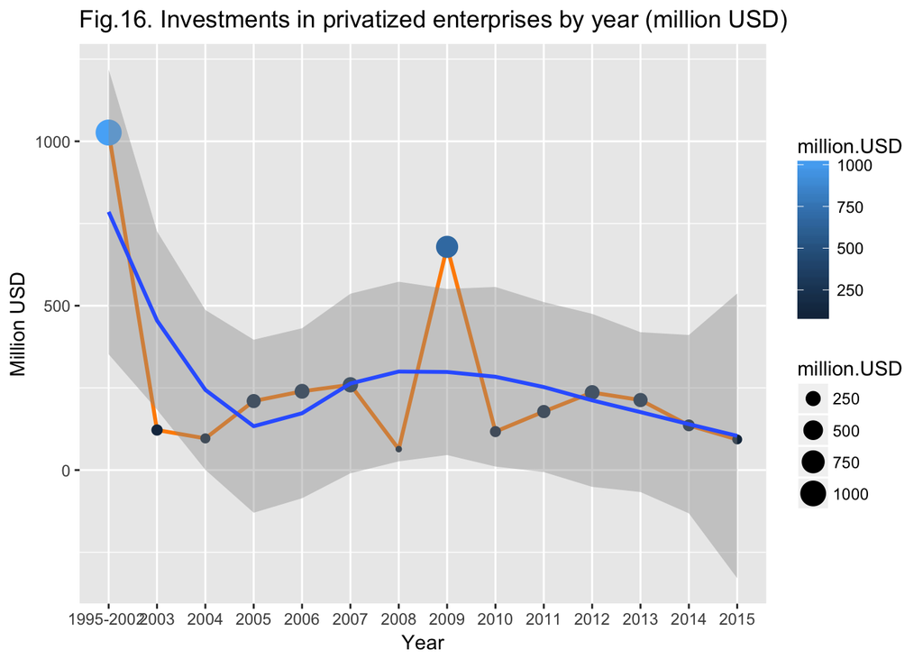

```r
ggplot(data = PrivatizedCompaniesInvestments, aes(x = Year, y = million.USD, group = 1))+
        geom_line(colour="darkorange", size = 1)+
        geom_point(aes(colour = million.USD, size = million.USD))+
        geom_smooth(method = "loess")+

        xlab("Year")+
        ylab("Million USD")+
        ggtitle("Fig.16. Investments in privatized enterprises by year (million USD)")
```

Итого, в приватизированные предприятия Украины частный собственник за 20 лет (с 1995 по 2015 год) вложил 3,6 млрд.дол.США. Если разделить эту сумму на все объекты приватизированной недвижимости, (28 тыс), получится, что каждое предприятие получало чуть более 6 тыс.дол. в год (или 130 тысяч долларов по накопительному итогу за все 20 лет). Даже, предположив, что инвестиции получали только крупные предприятия и объекты «недостроя», что составит 11 тыс.объектов (исключив из общего числа объекты малой приватизации), все равно сумма получится незначительной – 16,7 тыс.дол. ежегодно (или 330 тыс.долларов по накопительному итогу за 20 лет). Очевидно, что подобную сумму вряд ли можно счесть такой, которая в состоянии привести к качественным изменениям, позволяющим предприятиям стать конкурентоспособными на международном рынке, и говорить, например, о модернизации морально-устаревшего станочного парка или замены изношенных основных фондов, к сожалению, не приходится.

# ЭКОНОМИЧЕСКОЕ РАЗВИТИЕ УКРАИНЫ, 25 лет пути.

После 1991 года все страны бывшего СССР пережили глубокий экономический кризис, связанный с разрывом тесных экономических связей, большим количеством в экономике предприятий с незавершенным циклом производства, инфляцией, и т.д. Страны проводили экономические реформы, реструктуризировали промышленность, приватизировали ранее принадлежавшие государству предприятия.

Давайте рассмотрим несколько показателей экономического развития Украины, и для сравнения будем использовать аналогичные показатели и других стран, которые в 1990 году были в той же отправной точке, что и Украина, но выбрали разные пути развития – Беларусь, Россию (государственный капитализм) и Латвию, Литву (либеральная открытая экономика). После стремительного падения после распада СССР, ВВП Украины стабильно рос, «догнав» в 2005 году показатель 1992 года. Экономический кризис 2008 года отбросил его на несколько лет назад. Следующие 5 лет, ВВП показывал ежегодный прирост, пока очередной кризис, вызванный уже скорее политическими причинами, опять не уменьшил его в два раза, с 183 млрд. долларов до 90 млрд. (см.Рис. 19)[^18].

##### Рис.19. ВВП Украины 1992-2015 гг. (ном.дол.США).

```r
gdp_data_ua <- wb(country = c("UA"), indicator = "NY.GDP.MKTP.CD", startdate = 1990, enddate = 2015, removeNA = TRUE) %>% select(value, date, country)

for(i in 1:24){
       gdp_data_ua$value[i] <- gdp_data_ua$value[i]/1000000000
}

colnames(gdp_data_ua) <- c("GDP Billions USD", "Year", "Country")

gdp_data_ua
```

```
##    GDP Billions USD Year Country
## 1          90.61502 2015 Ukraine
## 2         133.50341 2014 Ukraine
## 3         183.31015 2013 Ukraine
## 4         175.78138 2012 Ukraine
## 5         163.15967 2011 Ukraine
## 6         136.01316 2010 Ukraine
## 7         117.22777 2009 Ukraine
## 8         179.99241 2008 Ukraine
## 9         142.71901 2007 Ukraine
## 10        107.75307 2006 Ukraine
## 11         86.14202 2005 Ukraine
## 12         64.88306 2004 Ukraine
## 13         50.13295 2003 Ukraine
## 14         42.39290 2002 Ukraine
## 15         38.00934 2001 Ukraine
## 16         31.26172 2000 Ukraine
## 17         31.58096 1999 Ukraine
## 18         41.88324 1998 Ukraine
## 19         50.15040 1997 Ukraine
## 20         44.55808 1996 Ukraine
## 21         48.21475 1995 Ukraine
## 22         52.54339 1994 Ukraine
## 23         65.60752 1993 Ukraine
## 24         71.89643 1992 Ukraine
```

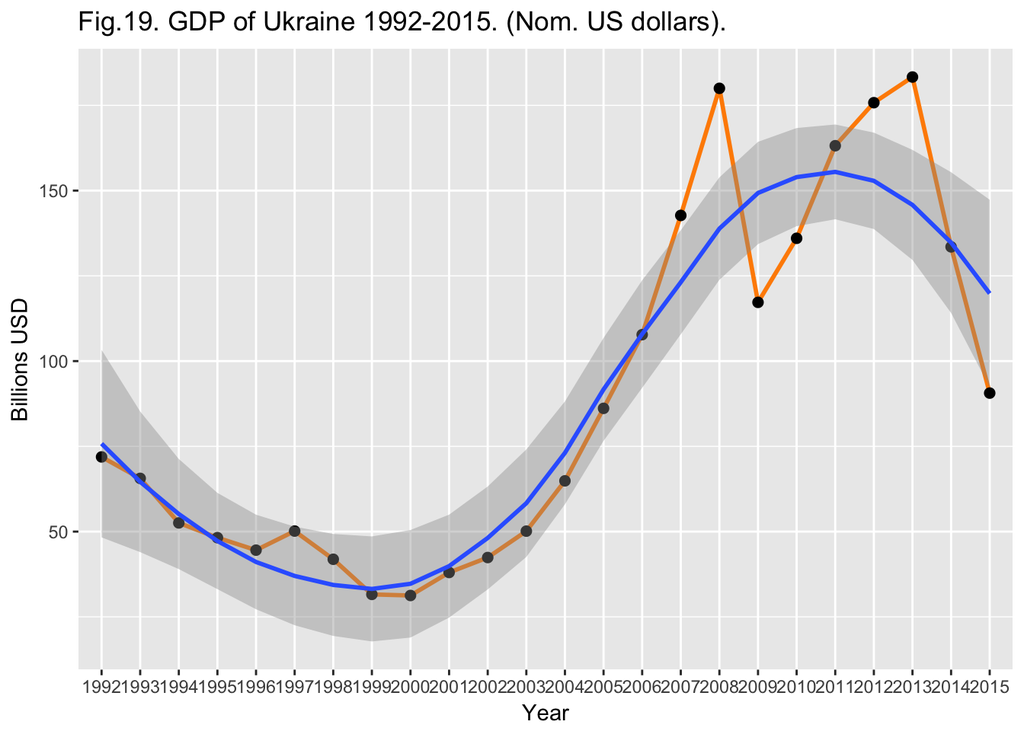

```r
ggplot(data = gdp_data_ua, aes(x = Year, y = `GDP Billions USD`, group = 1))+
        geom_line(colour="darkorange", size = 1)+
        geom_point(colour = "black", size = 2)+
        geom_smooth(method = "loess")+

        xlab("Year")+
        ylab("Billions USD")+
        ggtitle("Fig.19. GDP of Ukraine 1992-2015. (Nom. US dollars).")
```

##### Рис.20. ВВП по некоторым странам. 1992-2015 гг. (доллары США)[^19]

```r
gdp_data <- wb(country = c("UA","BY","LT","LV","RU"), indicator = "NY.GDP.MKTP.CD", startdate = 1990, enddate = 2015, removeNA = TRUE) %>% select(value, date, country)

for(i in 1:118){
       gdp_data$value[i] <- gdp_data$value[i]/1000000000
}

temp <- grep("1992|1995|2000|2010|2015", gdp_data$date)
gdp_selectedY <- data.frame()

for(i in temp){
        gdp_selectedY <- rbind(gdp_selectedY, gdp_data[i,])
}

colnames(gdp_selectedY) <- c("GDP Billions USD", "Year", "Country")

gdp_selectedY
```

```
##     GDP Billions USD Year            Country
## 1          54.608963 2015            Belarus
## 6          55.220933 2010            Belarus
## 16         12.736856 2000            Belarus
## 21         13.972638 1995            Belarus
## 24         17.022180 1992            Belarus
## 27         41.170729 2015          Lithuania
## 32         37.132564 2010          Lithuania
## 42         11.539211 2000          Lithuania
## 47          7.870782 1995          Lithuania
## 53         27.002832 2015             Latvia
## 58         23.765078 2010             Latvia
## 68          7.937759 2000             Latvia
## 73          5.788369 1995             Latvia
## 79       1331.207746 2015 Russian Federation
## 84       1524.916112 2010 Russian Federation
## 94        259.708496 2000 Russian Federation
## 99        395.531067 1995 Russian Federation
## 102       460.290557 1992 Russian Federation
## 105        90.615023 2015            Ukraine
## 110       136.013156 2010            Ukraine
## 120        31.261718 2000            Ukraine
## 125        48.214752 1995            Ukraine
## 128        71.896429 1992            Ukraine
```

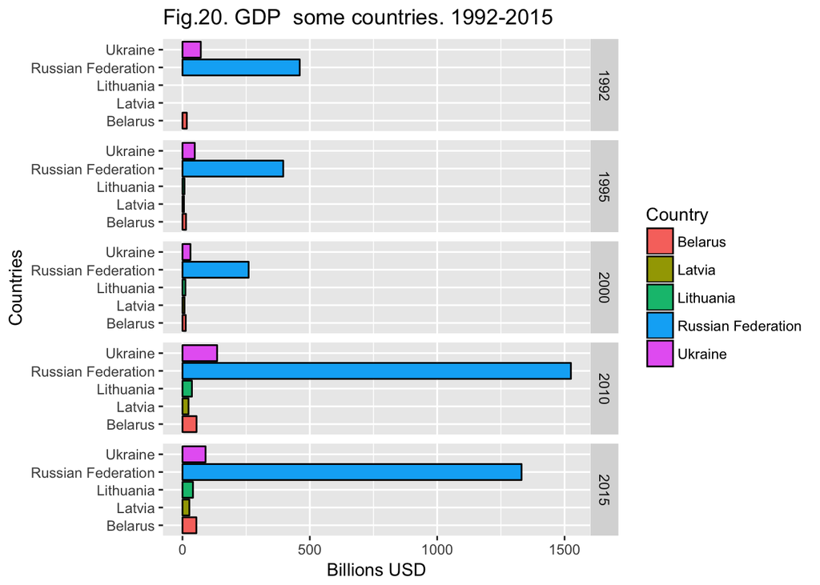

```r
ggplot(data = gdp_selectedY, aes(x = Country, y = `GDP Billions USD`, fill = Country))+
        geom_bar(colour="black", stat = "identity")+
        xlab("Countries")+
        ylab("Billions USD")+
        ggtitle("Fig.20. GDP  some countries. 1992-2015")+

        coord_flip()+

        facet_grid(Year~.)
```

```r
GDPgrowth <- data.frame()
countries <- c("Belarus", "Lithuania", "Latvia", "Russian Federation", "Ukraine")

for(i in countries){
        temp <- gdp_data %>% filter(country == i)
        c <- nrow(temp)
        temp2 <- data.frame(temp[1,3], ((temp[c,1]/temp[1,1])-1)*(-100))
        GDPgrowth <- rbind(GDPgrowth, temp2)
}

colnames(GDPgrowth) <- c("Country", "% of GDP growth")

GDPgrowth
```

```
##              Country % of GDP growth
## 1            Belarus        68.19277
## 2          Lithuania        80.88258
## 3             Latvia        78.56385
## 4 Russian Federation        61.17704
## 5            Ukraine        20.65728
```

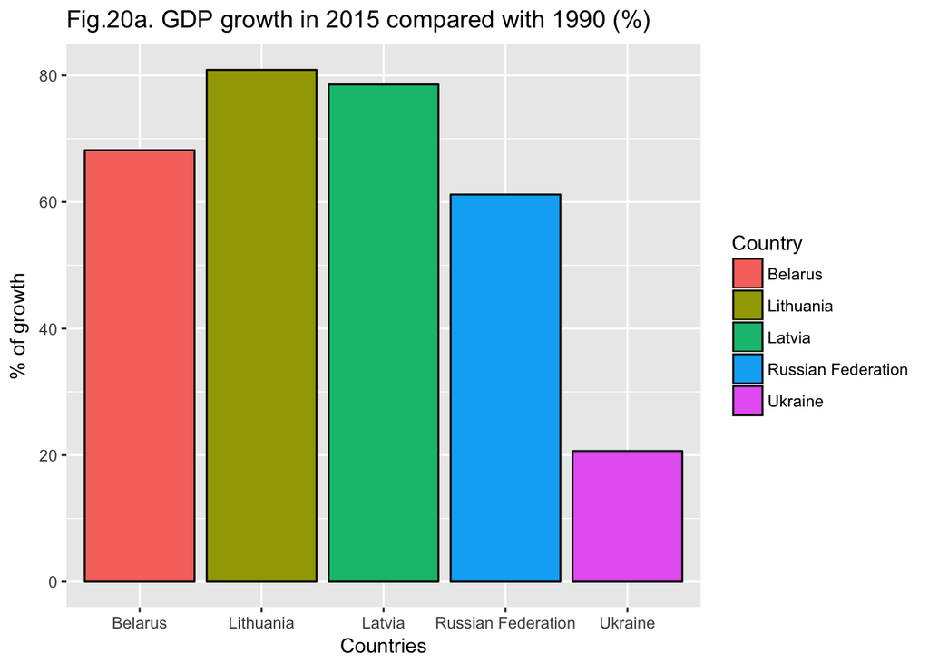

```r
ggplot(data = GDPgrowth, aes(x = Country, y = `% of GDP growth`, fill = Country))+
        geom_bar(colour="black", stat = "identity")+
        xlab("Countries")+
        ylab("% of growth")+
        ggtitle("Fig.20a. GDP growth in 2015 compared with 1990 (%)")
```

##### Рис.21. Доля промышленности в ВВП страны (%)[^20].

```r
industry_gdp <- wb(country = c("UA","BY","LT","LV","RU"), indicator = "NV.IND.TOTL.ZS", startdate = 1990, enddate = 2015, removeNA = TRUE) %>% select(value, date, country)

temp <- grep("1992|1995|2000|2010|2015", industry_gdp$date)
industry_gdp_selectedY <- data.frame()

for(i in temp){
        industry_gdp_selectedY <- rbind(industry_gdp_selectedY, industry_gdp[i,])
}

colnames(industry_gdp_selectedY) <- c("Industry (% of GDP)", "Year", "Country")

industry_gdp_selectedY
```

```
##     Industry (% of GDP) Year            Country
## 1              39.97420 2015            Belarus
## 6              42.20506 2010            Belarus
## 16             39.17020 2000            Belarus
## 21             36.96839 1995            Belarus
## 24             47.77980 1992            Belarus
## 27             30.18047 2015          Lithuania
## 32             29.06580 2010          Lithuania
## 42             29.59527 2000          Lithuania
## 47             31.51827 1995          Lithuania
## 53             23.11596 2015             Latvia
## 58             23.85878 2010             Latvia
## 68             26.53727 2000             Latvia
## 73             30.26274 1995             Latvia
## 79             32.60456 2015 Russian Federation
## 84             34.69617 2010 Russian Federation
## 94             37.94561 2000 Russian Federation
## 99             36.95603 1995 Russian Federation
## 102            43.00748 1992 Russian Federation
## 105            26.30227 2015            Ukraine
## 110            29.28666 2010            Ukraine
## 120            36.31656 2000            Ukraine
## 125            42.68424 1995            Ukraine
## 128            50.91000 1992            Ukraine
```

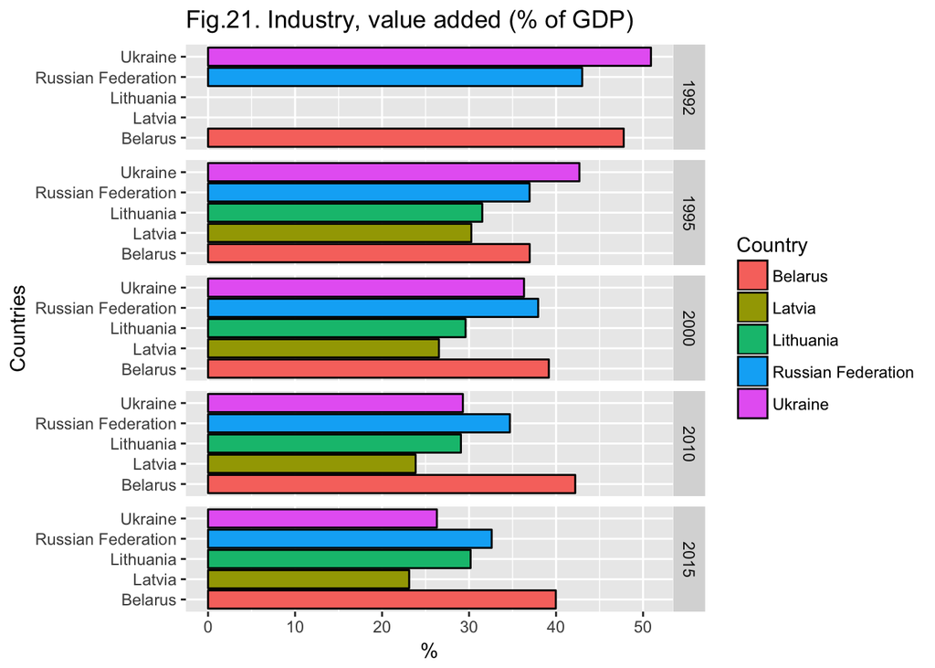

```r
ggplot(data = industry_gdp_selectedY, aes(x = Country, y = `Industry (% of GDP)`, fill = Country))+
        geom_bar(colour="black", stat = "identity")+
        xlab("Countries")+
        ylab("%")+
        ggtitle("Fig.21. Industry, value added (% of GDP)")+
        coord_flip()+
        facet_grid(Year~.)
```

##### Рис.22. Доля сельского хозяйства в ВВП страны (%)[^21].

```r
agro_gdp <- wb(country = c("UA","BY","LT","LV","RU"), indicator = "NV.AGR.TOTL.ZS", startdate = 1990, enddate = 2015, removeNA = TRUE) %>% select(value, date, country)

temp <- grep("1992|1995|2000|2010|2015", agro_gdp$date)
agro_gdp_selectedY <- data.frame()

for(i in temp){
        agro_gdp_selectedY <- rbind(agro_gdp_selectedY, agro_gdp[i,])
}

colnames(agro_gdp_selectedY) <- c("Agriculture (% of GDP)", "Year", "Country")

agro_gdp_selectedY
```

```
##     Agriculture (% of GDP) Year            Country
## 1                 7.795778 2015            Belarus
## 6                10.569386 2010            Belarus
## 16               14.153227 2000            Belarus
## 21               17.460441 1995            Belarus
## 24               23.572321 1992            Belarus
## 27                3.250462 2015          Lithuania
## 32                3.325049 2010          Lithuania
## 42                6.277472 2000          Lithuania
## 47               11.054790 1995          Lithuania
## 53                3.161636 2015             Latvia
## 58                4.405188 2010             Latvia
## 68                5.118209 2000             Latvia
## 73                8.895919 1995             Latvia
## 79                4.630079 2015 Russian Federation
## 84                3.867401 2010 Russian Federation
## 94                6.434522 2000 Russian Federation
## 99                7.160512 1995 Russian Federation
## 102               7.393539 1992 Russian Federation
## 105              14.036335 2015            Ukraine
## 110               8.421934 2010            Ukraine
## 120              17.082808 2000            Ukraine
## 125              15.400757 1995            Ukraine
## 128              20.356473 1992            Ukraine
```

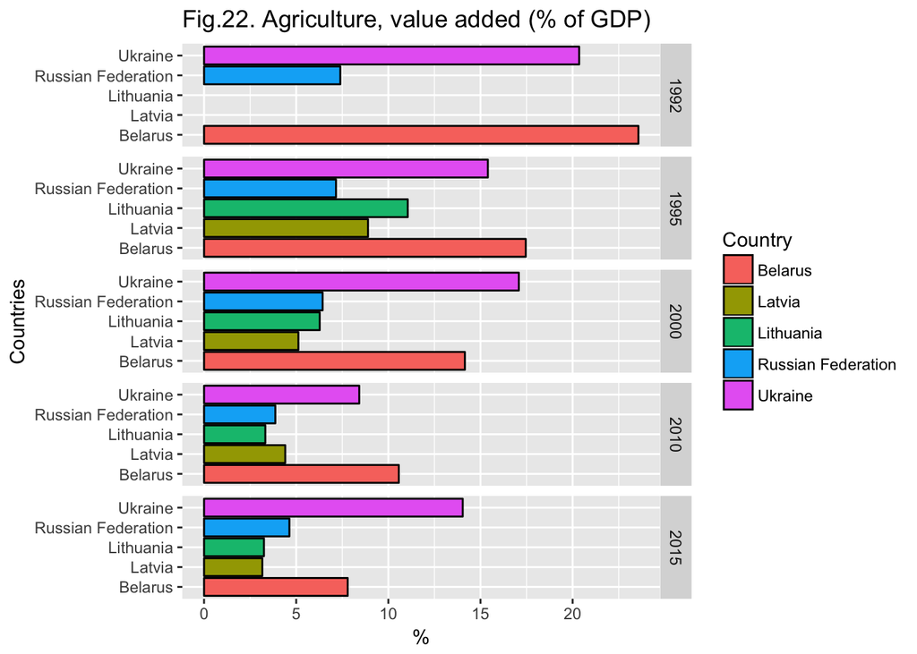

```r
ggplot(data = agro_gdp_selectedY, aes(x = Country, y = `Agriculture (% of GDP)`, fill = Country))+
        geom_bar(colour="black", stat = "identity")+
        xlab("Countries")+
        ylab("%")+
        ggtitle("Fig.22. Agriculture, value added (% of GDP)")+
        coord_flip()+
        facet_grid(Year~.)
```

##### Рис.23. Доля сферы услуг в ВВП страны (%)[^22].

```r
service_gdp <- wb(country = c("UA","BY","LT","LV","RU"), indicator = "NV.SRV.TETC.ZS", startdate = 1990, enddate = 2015, removeNA = TRUE) %>% select(value, date, country)

temp <- grep("1992|1995|2000|2010|2015", service_gdp$date)
service_gdp_selectedY <- data.frame()

for(i in temp){
        service_gdp_selectedY <- rbind(service_gdp_selectedY, service_gdp[i,])
}

colnames(service_gdp_selectedY) <- c("Services (% of GDP)", "Year", "Country")

service_gdp_selectedY
```

```
##     Services (% of GDP) Year            Country
## 1              52.23002 2015            Belarus
## 6              47.22556 2010            Belarus
## 16             46.67657 2000            Belarus
## 21             45.57117 1995            Belarus
## 24             28.64788 1992            Belarus
## 27             66.56907 2015          Lithuania
## 32             67.60916 2010          Lithuania
## 42             64.12726 2000          Lithuania
## 47             57.42694 1995          Lithuania
## 53             73.72241 2015             Latvia
## 58             71.73603 2010             Latvia
## 68             68.34452 2000             Latvia
## 73             60.84134 1995             Latvia
## 79             62.76536 2015 Russian Federation
## 84             61.43643 2010 Russian Federation
## 94             55.61987 2000 Russian Federation
## 99             55.88345 1995 Russian Federation
## 102            49.59898 1992 Russian Federation
## 105            59.66140 2015            Ukraine
## 110            62.29140 2010            Ukraine
## 120            46.60063 2000            Ukraine
## 125            41.91500 1995            Ukraine
## 128            28.73353 1992            Ukraine
```

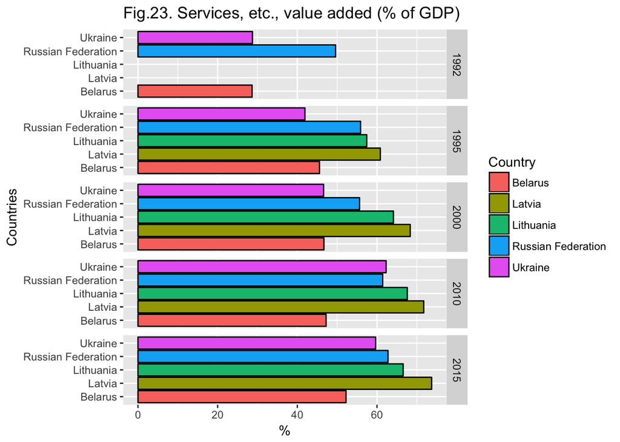

```r
ggplot(data = service_gdp_selectedY, aes(x = Country, y = `Services (% of GDP)`, fill = Country))+
        geom_bar(colour="black", stat = "identity")+
        xlab("Countries")+
        ylab("%")+
        ggtitle("Fig.23. Services, etc., value added (% of GDP)")+
        coord_flip()+
        facet_grid(Year~.)
```

```r
external_debt <- wb(country = c("UA","BY","LT","LV","RU"), indicator = "GC.DOD.TOTL.GD.ZS", startdate = 1990, enddate = 2015) %>% select(value, date, country)

colnames(external_debt) <- c("Government debt (% of GDP)", "Year", "Country")

#Данные внешнего государственного долга по странам и периодам
external_debt$Year <- as.factor(external_debt$Year)
external_debt
```

```
##     Government debt (% of GDP) Year            Country
## 1                    38.869017 2015            Belarus
## 2                    25.422592 2014            Belarus
## 3                    24.629697 2013            Belarus
## 4                    25.224401 2012            Belarus
## 5                    40.754852 2011            Belarus
## 6                    19.593715 2010            Belarus
## 7                    19.185184 2009            Belarus
## 8                    10.656634 2008            Belarus
## 9                     8.909261 2007            Belarus
## 10                    6.644402 2006            Belarus
## 11                    6.570221 2005            Belarus
## 14                   12.336686 2002            Belarus
## 15                   11.440617 2001            Belarus
## 16                   15.014452 2000            Belarus
```

[output cut: 44 more lines]

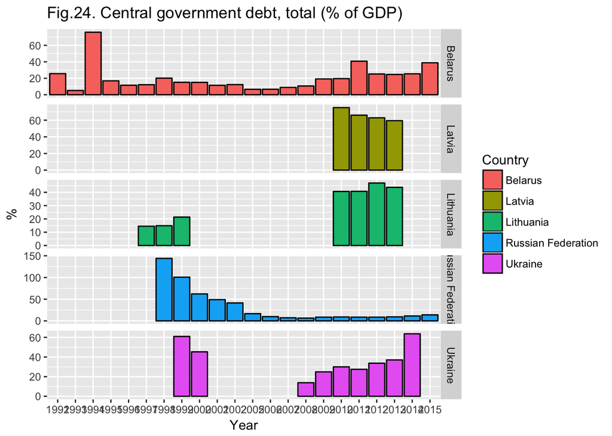

```r
ggplot(data = external_debt, aes(x = Year, y = `Government debt (% of GDP)`, fill = Country))+
        geom_bar(colour="black", stat = "identity")+
        xlab("Year")+
        ylab("%")+
        ggtitle("Fig.24. Central government debt, total (% of GDP)")+
        facet_grid(Country~., scales = "free")
```

[^1]: По данным ежегодных отчетов Фонда государственного имущества Украины http://www.spfu.gov.ua/ru/documents/docs-list/spf-reports.html . Авторская таблица https://github.com/i2alex/Privatization-in-Ukraine.-1992-2015/blob/master/Data/privatization_ua.xlsx
[^2]: Группы объектов приватизации: A - небольшие объекты, B, Г - большие и стратегические предприятия, Д - объекты незавершенного строительства, E - акции и доли, принадлежащие государству в уставном капитале хозяйственных обществ, Ж - социально-культурные объекты (образование, здравоохранение, научно-исследовательские компании).Более детально см.приложение 1.
[^3]: Отчет Фонда государственного имущества Украины за 2004 г. Приложение 5. (к сожалению, нумерация страниц в приложениях данного отчета отсутствует) http://www.spfu.gov.ua/ru/documents/docs-list/spf-reports.html
[^4]: УМОВИ ЗАВЕРШЕННЯ ПРИВАТИЗАЦІЇ В УКРАЇНІ. Аналітичний звіт та рекомендації для Державної програми приватизації. Володимир Дубровський, Олександр Пасхавер, Лідія Верховодова, Барбара Блащик. Варшава, Київ - грудень 2007
[^5]: “Статистичний щорічник України за 2013 рік”. ДЕРЖАВНА СЛУЖБА СТАТИСТИКИ УКРАЇНИ. За редакцією О.Г.Осауленка. Відповідальний за випуск. О.А. Вишневська. 2013. library.oneu.edu.ua/files/StatSchorichnyk_Ukrainy_2013.pdf. Авторская таблица доступна по ссылке https://github.com/i2alex/Privatization-in-Ukraine.-1992-2015/blob/master/Data/number_of_enterprices_%20by_ownership_ua.xlsx
[^6]: http://www.ebrd.com/what-we-do/economic-research-and-data/data/forecasts-macro-data-transition-indicators.html
[^7]: По данным ежегодных отчетов Фонда государственного имущества Украины http://www.spfu.gov.ua/ru/documents/docs-list/spf-reports.html. Авторская таблица доступна по ссылке https://github.com/i2alex/Privatization-in-Ukraine.-1992-2015/blob/master/Data/ukr_budget_receipt_comulative_total.xlsx
[^8]: Авторская таблица доступна по ссылке https://github.com/i2alex/Privatization-in-Ukraine.-1992-2015/blob/master/Data/ukr_budget_receipt_per_year.xlsx
[^9]: Данные финансового портала МинФин http://index.minfin.com.ua/budget/ Данные авторской таблицы можно загрузить https://github.com/i2alex/Privatization-in-Ukraine.-1992-2015/blob/master/Data/privatization_receipts_in_total_ukr_budget_receipts_per_year.xlsx
[^10]: http://voxukraine.org/2015/01/23/outsourcing-privatization-attracting-capital-while-raising-efficiency/
[^11]: Авторская таблица, составленная по данным отчета Фонда государственного имущества Украины за 2015 год доступна по ссылке https://github.com/i2alex/Privatization-in-Ukraine.-1992-2015/blob/master/Data/privatization_contracts_over_control.xlsx
[^12]: Авторская таблица с данными доступна по ссылке https://github.com/i2alex/Privatization-in-Ukraine.-1992-2015/blob/master/Data/violations_in_%20the_%20contracts_over_control.xlsx
[^13]: Авторская таблица с данными доступна по ссылке https://github.com/i2alex/Privatization-in-Ukraine.-1992-2015/blob/master/Data/penalties_per_violation_in_the_contracts_over_control.xlsx
[^14]: Авторы хотели бы проанализировать все показатели (в первую очередь, сохранение основных видов деятельности и сохранение объемов производства.), но, к сожалению, подробная открытая статистика для этих показателей в нашей стране отсутствует. Данные, и то не полные (не все года), авторы смогли собрать из тех же отчетов Фонда госимущества только по приведенным в этой работе показателям: объем привлеченных инвестиций, количество предприятий, взявших обязательства касательно рабочих мест, вновь созданные рабочие места).
[^15]: Авторская таблица, составленная на основе данных отчета Фонда государственного имущества Украины за 2015 год доступна по ссылке https://github.com/i2alex/Privatization-in-Ukraine.-1992-2015/blob/master/Data/investments_in_privatized_companies.xlsx
[^16]: Авторская таблица, составленная на основе данных отчета Фонда государственного имущества Украины за 2015 год доступна по ссылке https://github.com/i2alex/Privatization-in-Ukraine.-1992-2015/blob/master/Data/investments_in_privatized_companies.xlsx
[^17]: http://ua.censor.net.ua/news/405508/u_slujbi_zayinyatosti_na_obliku_stoyit_na_10_menshe_lyudeyi_nij_mynulogo_roku_rozenko
[^18]: http://data.worldbank.org/indicator/NY.GDP.PCAP.CD
[^19]: http://data.worldbank.org/indicator/NY.GDP.PCAP.CD
[^20]: http://data.worldbank.org/indicator/NV.IND.TOTL.ZS
[^21]: http://data.worldbank.org/indicator/NV.AGR.TOTL.ZS
[^22]: http://data.worldbank.org/indicator/NV.SRV.TETC.ZS
[^23]: http://data.worldbank.org/indicator/GC.DOD.TOTL.GD.ZS